# 2501report_ShenHongshan

Shen Hongshan

2025-11-20

# Predicting Mental Health Treatment Needs Based on Workplace Factors and Demographic Characteristics

### Author: Shen Hongshan (3036290936)

### Data source: [Kaggle Mental Health in Tech Survey](https://www.kaggle.com/datasets/osmi/mental-health-in-tech-survey/data)

## **Project Overview**

### **Proposal**

> **Research Questions:** 1. Which workplace factors and demographic characteristics are most predictive of needing mental health treatment? 2. How can we build a machine learning model to identify individuals who would benefit from mental health intervention based on their survey responses?

**Importance:**  
Mental health issues in the workplace have deep economic and social consequences. Early identification of at-risk individuals enables timely intervention, improved well-being, and productivity.

**Challenges:**  
- Handling class imbalance in responses (many may not report needing treatment). - Missing data and survey noise (subjectivity in self-reporting). - Potential bias in responses.

**Existing Work:**  
Previous studies and open-source projects have shown that factors such as *work interference*, *family history*, and *employer support* strongly impact mental health needs.

**Methodology:**  
1. Data loading and exploration 2. Data cleaning: remove irrelevant columns, handle missingness & outliers 3. Variable standardisation 4. Visualisation of key factors 5. Statistical modelling: logistic regression for predictor analysis + subgroup analyses 6. Summary of findings and implications for workplace mental health policy

## **1. Data Loading & Exploration**

```r
library(tidyverse)
library(readr)
library(dplyr)
library(ggplot2)
library(knitr)
library(caret)
library(broom)
library(car)  # for VIF
library(pROC)

# Read the dataset (make sure 'survey.csv' is in the same folder)
survey_data <- read_csv("survey.csv")

# Overview: dimensions and column names
cat("Dataset dimensions:", paste(dim(survey_data), collapse=" x "), "\n")
```

```
## Dataset dimensions: 1259 x 27
```

```r
cat("Column names:\n")
```

```
## Column names:
```

```r
names(survey_data)
```

```
##  [1] "Timestamp"                 "Age"
##  [3] "Gender"                    "Country"
##  [5] "state"                     "self_employed"
##  [7] "family_history"            "treatment"
##  [9] "work_interfere"            "no_employees"
## [11] "remote_work"               "tech_company"
## [13] "benefits"                  "care_options"
## [15] "wellness_program"          "seek_help"
## [17] "anonymity"                 "leave"
## [19] "mental_health_consequence" "phys_health_consequence"
## [21] "coworkers"                 "supervisor"
## [23] "mental_health_interview"   "phys_health_interview"
## [25] "mental_vs_physical"        "obs_consequence"
## [27] "comments"
```

## **2. Data Preparation & Cleaning**

### 2.1 Handle Missing Values, Drop Irrelevant Columns

```r
# Missing value summary
missing_summary <- sort(colSums(is.na(survey_data)), decreasing = TRUE)
cat("Missing values per column:\n")
```

```
## Missing values per column:
```

```r
kable(data.frame(Feature=names(missing_summary), Missing=missing_summary))
```

|  | Feature | Missing |
| --- | --- | --- |
| comments | comments | 1096 |
| state | state | 515 |
| work_interfere | work_interfere | 264 |
| self_employed | self_employed | 18 |
| Timestamp | Timestamp | 0 |
| Age | Age | 0 |
| Gender | Gender | 0 |
| Country | Country | 0 |
| family_history | family_history | 0 |
| treatment | treatment | 0 |
| no_employees | no_employees | 0 |
| remote_work | remote_work | 0 |
| tech_company | tech_company | 0 |
| benefits | benefits | 0 |
| care_options | care_options | 0 |
| wellness_program | wellness_program | 0 |
| seek_help | seek_help | 0 |
| anonymity | anonymity | 0 |
| leave | leave | 0 |
| mental_health_consequence | mental_health_consequence | 0 |
| phys_health_consequence | phys_health_consequence | 0 |
| coworkers | coworkers | 0 |
| supervisor | supervisor | 0 |
| mental_health_interview | mental_health_interview | 0 |
| phys_health_interview | phys_health_interview | 0 |
| mental_vs_physical | mental_vs_physical | 0 |
| obs_consequence | obs_consequence | 0 |

```r
# Drop columns with too many NAs or irrelevant for analysis (comments, Timestamp, state)
survey_clean <- survey_data %>%
  select(-Timestamp, -comments, -state)

cat("Columns left after removal:", paste(names(survey_clean), collapse=", "))
```

[output not shown]

### 2.2 Standardize Variables: Gender, Age, Conversion

```r
survey_clean <- survey_clean |>
  mutate(
    # Gender standardization
    Gender = case_when(
      str_detect(tolower(Gender), "^m|^male|^man|^maile|^make|^mal$|^male-ish|^guy") ~ "Male",
      str_detect(tolower(Gender), "^f|^female|^woman|^femaile|^femake|^fem") ~ "Female",
      TRUE ~ "Transgender/Non-binary/Others"
    ),
    # Convert character columns to factors
    across(where(is.character), as.factor)
  )

# Handle age outliers
survey_clean <- survey_clean |>
  mutate(
    Age = case_when(
      Age < 18 ~ NA,    # Remove unrealistic ages
      Age > 100 ~ NA,
      TRUE ~ Age
    )
  ) |>
  filter(!is.na(Age))  # Remove rows with invalid ages
```

### 2.3 Target Variable Check

```r
#Distribution of treatment status
as.data.frame(table(survey_clean$treatment))
```

```
##   Var1 Freq
## 1   No  619
## 2  Yes  632
```

```r
#Proportion table
as.data.frame(prop.table(table(survey_clean$treatment)))
```

```
##   Var1      Freq
## 1   No 0.4948042
## 2  Yes 0.5051958
```

## **3. Exploratory Data Analysis & Visualization**

### 3.1 Demographic Overview

```r
demographic_summary <- survey_clean %>%
  summarise(
    n = n(),
    avg_age = mean(Age, na.rm = TRUE),
    male_pct = round(mean(Gender == "Male")*100,1),
    female_pct = round(mean(Gender == "Female")*100,1),
    treatment_rate = round(mean(treatment == "Yes")*100,1)
  )
#Sample Demographic Summary
demographic_summary
```

```
## # A tibble: 1 × 5
##       n avg_age male_pct female_pct treatment_rate
##   <int>   <dbl>    <dbl>      <dbl>          <dbl>
## 1  1251    32.1     78.7       19.8           50.5
```

- Treatment rate by gender

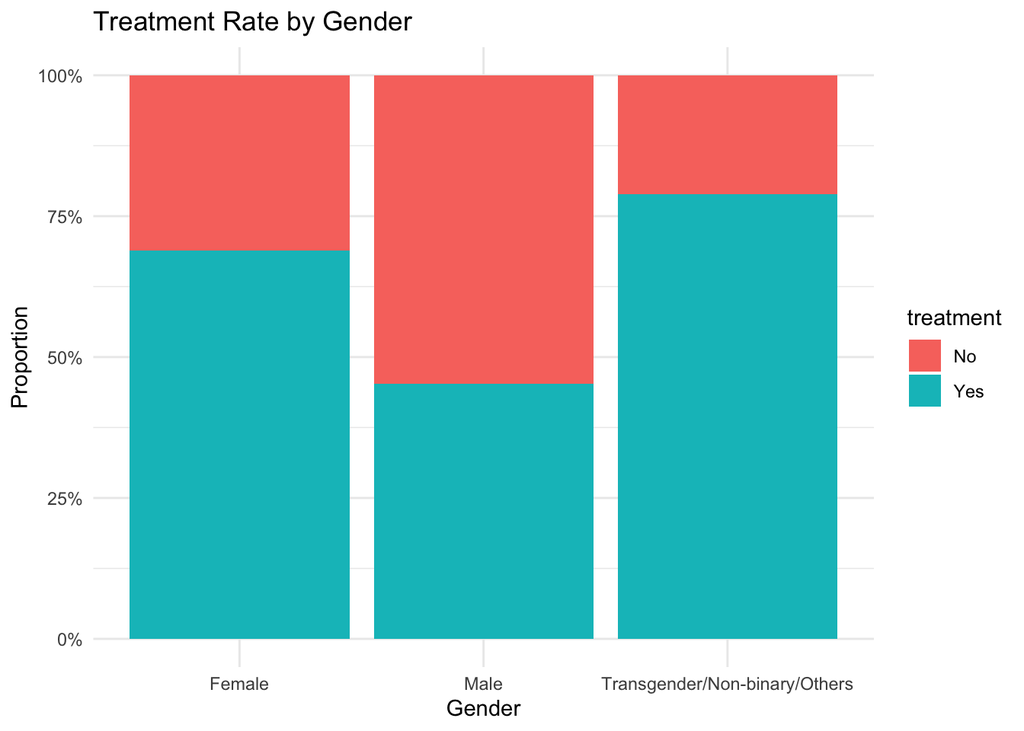

```r
ggplot(survey_clean, aes(x=Gender, fill=treatment)) +
  geom_bar(position="fill") +
  labs(y="Proportion", title="Treatment Rate by Gender") +
  scale_y_continuous(labels=scales::percent) +
  theme_minimal()
```

- Treatment rate by family history

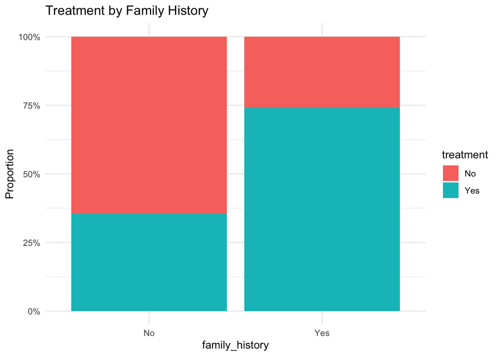

```r
ggplot(survey_clean, aes(x=family_history, fill=treatment)) +
  geom_bar(position="fill") +
  labs(title="Treatment by Family History", y="Proportion") +
  scale_y_continuous(labels=scales::percent) +
  theme_minimal()
```

- Treatment rate by work interference

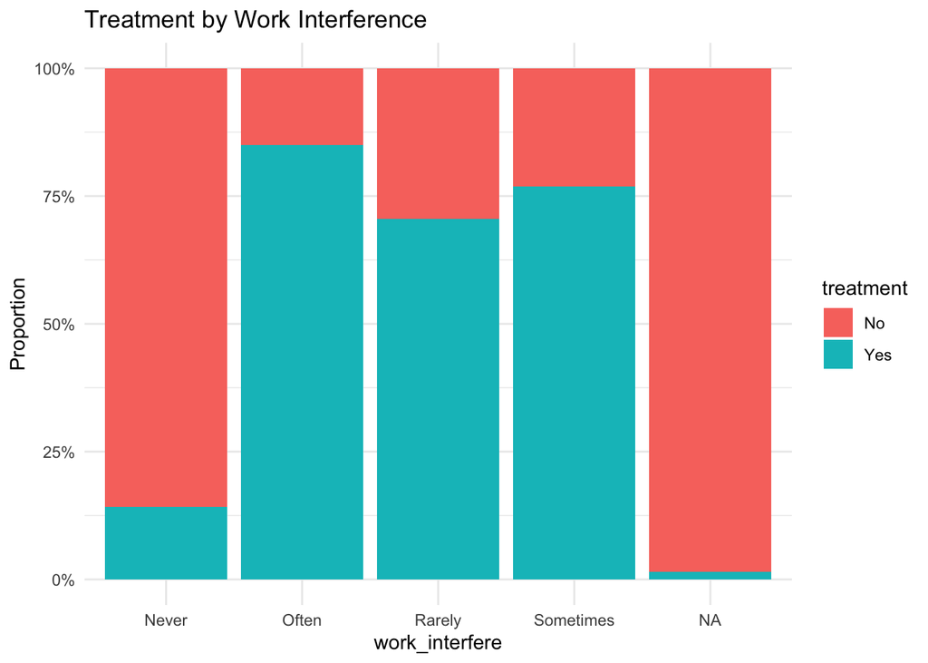

```r
ggplot(survey_clean, aes(x=work_interfere, fill=treatment)) +
  geom_bar(position="fill") +
  labs(title="Treatment by Work Interference", y="Proportion") +
  scale_y_continuous(labels=scales::percent) +
  theme_minimal()
```

#### **Insight:**

*Individuals with family history of mental illness and those reporting frequent work interference are much more likely to seek treatment.*

## **4. Modelling & Statistical Analysis**

### 4.1 Prepare Data for Modelling

```r
# Create binary target variable
survey_model <- survey_clean %>%
  mutate(
    treatment_binary = ifelse(treatment == "Yes", 1, 0)
  )

# Select key predictors as per project proposal
predictors <- c(
  "Age", "Gender", "family_history",
  "work_interfere", "no_employees", "remote_work", "tech_company",
  "benefits", "care_options", "wellness_program", "seek_help",
  "anonymity", "leave",
  "mental_health_consequence", "phys_health_consequence",
  "coworkers", "supervisor", "mental_health_interview",
  "mental_vs_physical", "obs_consequence"
)

model_data <- survey_model %>% select(all_of(c("treatment_binary", predictors))) %>% na.omit()
cat("Final modelling data shape:", dim(model_data), "\n")
```

```
## Final modelling data shape: 989 21
```

### 4.2 Split Data: Train/Test

```r
set.seed(123)
train_idx <- createDataPartition(model_data$treatment_binary, p=0.7, list=FALSE)
train_data <- model_data[train_idx, ]
test_data <- model_data[-train_idx, ]

cat("Training set size:", nrow(train_data), "\n")
```

```
## Training set size: 693
```

```r
cat("Test set size:", nrow(test_data), "\n")
```

```
## Test set size: 296
```

### 4.3 Logistic Regression Model

```r
logit_model <- glm(treatment_binary ~ ., data=train_data, family="binomial")

cat("Model summary (logistic regression):\n")
```

```
## Model summary (logistic regression):
```

```r
summary(logit_model)
```

```
##
## Call:
## glm(formula = treatment_binary ~ ., family = "binomial", data = train_data)
##
## Coefficients:
##                                     Estimate Std. Error z value Pr(>|z|)
## (Intercept)                         -1.62129    0.93778  -1.729  0.08383 .
## Age                                  0.01341    0.01504   0.892  0.37263
## GenderMale                          -0.94125    0.30195  -3.117  0.00183 **
## GenderTransgender/Non-binary/Others  0.16736    0.88073   0.190  0.84929
## family_historyYes                    1.07980    0.22094   4.887 1.02e-06 ***
## work_interfereOften                  3.20380    0.40344   7.941 2.00e-15 ***
## work_interfereRarely                 2.16495    0.33767   6.411 1.44e-10 ***
## work_interfereSometimes              2.69533    0.30096   8.956  < 2e-16 ***
## no_employees100-500                  0.10903    0.44232   0.246  0.80530
## no_employees26-100                   0.56144    0.38436   1.461  0.14409
## no_employees500-1000                 0.51866    0.61940   0.837  0.40239
## no_employees6-25                     0.53811    0.36047   1.493  0.13549
## no_employeesMore than 1000           0.21920    0.43345   0.506  0.61307
## remote_workYes                      -0.06532    0.24588  -0.266  0.79050
## tech_companyYes                     -0.21364    0.28993  -0.737  0.46121
## benefitsNo                           0.01926    0.31740   0.061  0.95162
## benefitsYes                          0.51232    0.31592   1.622  0.10487
## care_optionsNot sure                -0.67520    0.28425  -2.375  0.01753 *
## care_optionsYes                      0.64337    0.29235   2.201  0.02776 *
## wellness_programNo                  -0.23976    0.37723  -0.636  0.52505
## wellness_programYes                 -0.48116    0.44213  -1.088  0.27647
## seek_helpNo                         -0.54037    0.30590  -1.766  0.07731 .
## seek_helpYes                        -0.40459    0.37508  -1.079  0.28073
## anonymityNo                         -0.44076    0.49390  -0.892  0.37217
## anonymityYes                         0.41645    0.28055   1.484  0.13770
## leaveSomewhat difficult              0.45761    0.38431   1.191  0.23376
## leaveSomewhat easy                  -0.24279    0.28057  -0.865  0.38686
## leaveVery difficult                  0.39248    0.43557   0.901  0.36755
## leaveVery easy                       0.16438    0.34794   0.472  0.63662
## mental_health_consequenceNo          0.18480    0.30345   0.609  0.54252
## mental_health_consequenceYes        -0.24035    0.32155  -0.747  0.45478
## phys_health_consequenceNo           -0.28107    0.28870  -0.974  0.33027
## phys_health_consequenceYes          -0.37199    0.52422  -0.710  0.47796
## coworkersSome of them                0.55667    0.31678   1.757  0.07887 .
## coworkersYes                         0.86898    0.43922   1.978  0.04788 *
## supervisorSome of them              -0.52509    0.31424  -1.671  0.09472 .
## supervisorYes                       -0.56187    0.34712  -1.619  0.10552
## mental_health_interviewNo            0.25673    0.31842   0.806  0.42009
## mental_health_interviewYes           1.68804    0.79791   2.116  0.03438 *
## mental_vs_physicalNo                -0.23818    0.28046  -0.849  0.39574
## mental_vs_physicalYes               -0.11750    0.29518  -0.398  0.69060
## obs_consequenceYes                   0.39575    0.33748   1.173  0.24093
## ---
## Signif. codes:  0 '***' 0.001 '**' 0.01 '*' 0.05 '.' 0.1 ' ' 1
##
## (Dispersion parameter for binomial family taken to be 1)
##
##     Null deviance: 896.68  on 692  degrees of freedom
## Residual deviance: 602.33  on 651  degrees of freedom
## AIC: 686.33
##
## Number of Fisher Scoring iterations: 5
```

#### Multicollinearity check

```r
cat("VIF values (multicollinearity diagnosis):\n")
```

```
## VIF values (multicollinearity diagnosis):
```

```r
print(vif(logit_model))
```

```
##                               GVIF Df GVIF^(1/(2*Df))
## Age                       1.269908  1        1.126902
## Gender                    1.195424  2        1.045636
## family_history            1.124165  1        1.060266
## work_interfere            1.389782  3        1.056390
## no_employees              2.648603  5        1.102305
## remote_work               1.196434  1        1.093816
## tech_company              1.183833  1        1.088041
## benefits                  2.848931  2        1.299183
## care_options              2.002265  2        1.189544
## wellness_program          2.489339  2        1.256091
## seek_help                 2.877937  2        1.302478
## anonymity                 1.771001  2        1.153598
## leave                     2.044300  4        1.093498
## mental_health_consequence 3.110453  2        1.328024
## phys_health_consequence   1.777233  2        1.154612
## coworkers                 2.140260  2        1.209530
## supervisor                2.504518  2        1.258001
## mental_health_interview   1.429320  2        1.093408
## mental_vs_physical        1.980414  2        1.186285
## obs_consequence           1.262828  1        1.123756
```

#### Significant predictors (p < .05)

```r
significant_predictors <- broom::tidy(logit_model) %>%
  filter(p.value < 0.05 & term != "(Intercept)")
kable(significant_predictors, caption="Significant Predictors")
```

Significant Predictors

| term | estimate | std.error | statistic | p.value |
| --- | --- | --- | --- | --- |
| GenderMale | -0.9412452 | 0.3019542 | -3.117179 | 0.0018259 |
| family_historyYes | 1.0798049 | 0.2209441 | 4.887232 | 0.0000010 |
| work_interfereOften | 3.2037989 | 0.4034400 | 7.941202 | 0.0000000 |
| work_interfereRarely | 2.1649539 | 0.3376707 | 6.411435 | 0.0000000 |
| work_interfereSometimes | 2.6953252 | 0.3009577 | 8.955826 | 0.0000000 |
| care_optionsNot sure | -0.6751979 | 0.2842521 | -2.375349 | 0.0175324 |
| care_optionsYes | 0.6433679 | 0.2923531 | 2.200653 | 0.0277606 |
| coworkersYes | 0.8689759 | 0.4392155 | 1.978473 | 0.0478754 |
| mental_health_interviewYes | 1.6880442 | 0.7979141 | 2.115571 | 0.0343813 |

### 4.4 Model Evaluation

#### Prediction (training set)

```r
train_data$predicted_prob <- predict(logit_model, type="response")
train_data$predicted_class <- ifelse(train_data$predicted_prob > 0.5, 1, 0)
train_conf <- confusionMatrix(as.factor(train_data$predicted_class), as.factor(train_data$treatment_binary))
print(train_conf)
```

```
## Confusion Matrix and Statistics
##
##           Reference
## Prediction   0   1
##          0 148  36
##          1  94 415
##
##                Accuracy : 0.8124
##                  95% CI : (0.7813, 0.8408)
##     No Information Rate : 0.6508
##     P-Value [Acc > NIR] : < 2.2e-16
##
##                   Kappa : 0.563
##
##  Mcnemar's Test P-Value : 5.756e-07
##
##             Sensitivity : 0.6116
##             Specificity : 0.9202
##          Pos Pred Value : 0.8043
##          Neg Pred Value : 0.8153
##              Prevalence : 0.3492
##          Detection Rate : 0.2136
##    Detection Prevalence : 0.2655
##       Balanced Accuracy : 0.7659
##
##        'Positive' Class : 0
##
```

#### Prediction (test set) and ROC Curve

```r
test_data$predicted_prob <- predict(logit_model, newdata=test_data, type="response")
test_data$predicted_class <- ifelse(test_data$predicted_prob > 0.5, 1, 0)

test_conf <- confusionMatrix(as.factor(test_data$predicted_class), as.factor(test_data$treatment_binary))
print(test_conf)
```

```
## Confusion Matrix and Statistics
##
##           Reference
## Prediction   0   1
##          0  75  19
##          1  44 158
##
##                Accuracy : 0.7872
##                  95% CI : (0.7361, 0.8324)
##     No Information Rate : 0.598
##     P-Value [Acc > NIR] : 3.597e-12
##
##                   Kappa : 0.5415
##
##  Mcnemar's Test P-Value : 0.002497
##
##             Sensitivity : 0.6303
##             Specificity : 0.8927
##          Pos Pred Value : 0.7979
##          Neg Pred Value : 0.7822
##              Prevalence : 0.4020
##          Detection Rate : 0.2534
##    Detection Prevalence : 0.3176
##       Balanced Accuracy : 0.7615
##
##        'Positive' Class : 0
##
```

```r
roc_curve <- roc(test_data$treatment_binary, test_data$predicted_prob)
cat("AUC on test:", auc(roc_curve), "\n")
```

```
## AUC on test: 0.8434696
```

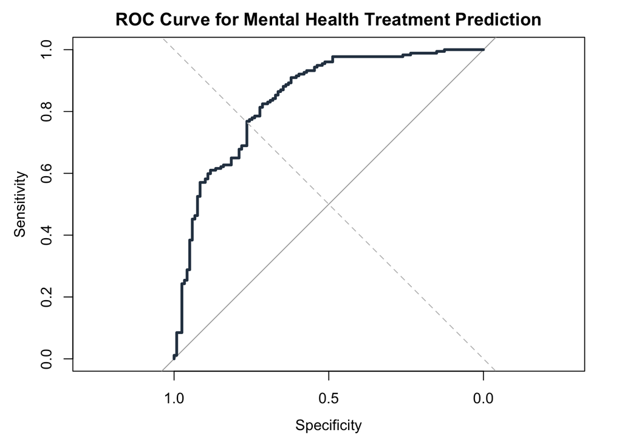

```r
plot(roc_curve, main="ROC Curve for Mental Health Treatment Prediction", col="#2c3e50", lwd=3)
abline(a=0, b=1, col="grey", lty=2)
```

#### Feature Importance Plot

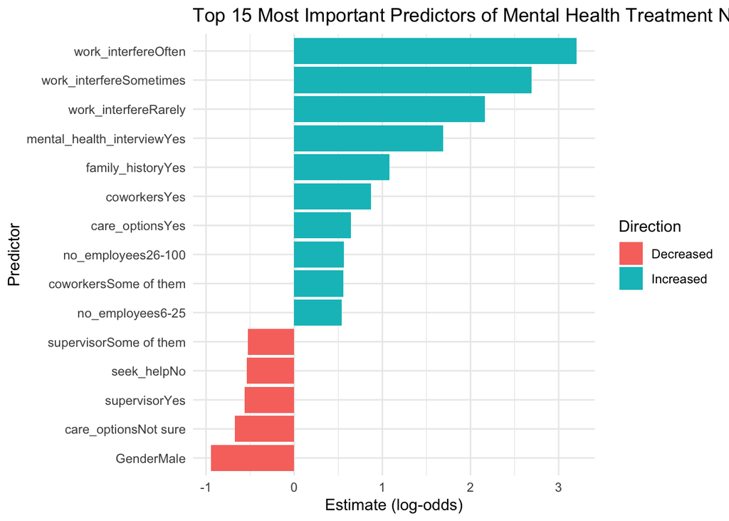

```r
feature_importance <- broom::tidy(logit_model) %>%
  filter(term != "(Intercept)") %>%
  mutate(odds_ratio=exp(estimate),
         direction=ifelse(estimate>0,"Increased","Decreased")) %>%
  arrange(desc(abs(estimate)))
top_features <- feature_importance %>% head(15)

ggplot(top_features, aes(x=reorder(term, estimate), y=estimate, fill=direction)) +
  geom_col() +
  coord_flip() +
  labs(title="Top 15 Most Important Predictors of Mental Health Treatment Need",
       x="Predictor", y="Estimate (log-odds)", fill="Direction") +
  theme_minimal()
```